# SARS-CoV-2 Análisis

## Análisis de las variantes de SARS-CoV-2 en los 20 países con mayor número de infectados

1. USA - USA - MZ015520
2. India - IND - MT434757
3. Brasil - BRA - MT844030
4. France - FRA - MW322968
5. Russia - RUS - MW332241
6. Turkey - TUR - MW306668
7. UK - GBR - MT906650
8. Italy - ITA - MW642250
9. Spain - ESP - MW769774
10. Germany - DEU - MT582499
11. Argentina - ARG - MW633909
12. Colombia - COL - MT470219
13. Poland - POL - MT775833
14. Iran - IRN - MT994881
15. Mexico - MEX - MW595909
16. Ukraine - UKR - No results found in NCBI
17. Peru - PER - MT263074
18. Indonesia - IDN - No results found in NCBI
19. Czech Rep. - CZE - MT517434
20. South Africa - ZAF - MT324062
21. Netherlands - NLD - MT396266
22. Canada - CAN - MW309429

```r
library(ggplot2)    #Plots
library(ape)        #Virus search
library(magrittr)   #Pipe operator(%>%)
library(DECIPHER)   #DNAStringSet, alignment and more
library(reshape2)   #Distance Matrix to Dataframe
library(ggtree)     #PlotTree
library(msa)        #Handle MSA (multiple alignment sequence)
library(ggmsa)      #Plot MSA
```

(Consultar base de datos)

```r
virusCountries <- c("USA","IND","BRA","FRA","RUS",
                    "TUR","GBR","ITA","ESP","DEU",
                    "ARG","COL","POL","IRN","MEX",
                    "PER","CZE","ZAF","NLD","CAN")
virusAcc <-       c("MZ015520","MT434757","MT844030","MW322968","MW332241",
                    "MW306668","MT906650","MW642250","MW769774","MT582499",
                    "MW633909","MT470219","MT775833","MT994881","MW595909",
                    "MT263074","MT517434","MT324062","MT396266","MW309429")

virusBin <- read.GenBank(virusAcc) #RUN ONCE
virus <- virusBin %>% as.character %>% lapply(.,paste0,collapse="") %>% unlist %>% DNAStringSet   #from DNAbin to DNAStringSet
```

### Longitudes de los virus

```r
data.frame("Virus"=virusAcc,
           "País"=virusCountries,
           "Longitud"=virus@ranges@width);
```

| Virus | País | Longitud |
| --- | --- | --- |
| MZ015520 | USA | 29854 |
| MT434757 | IND | 29817 |
| MT844030 | BRA | 29837 |
| MW322968 | FRA | 29903 |
| MW332241 | RUS | 29826 |
| MW306668 | TUR | 29867 |
| MT906650 | GBR | 29896 |
| MW642250 | ITA | 29859 |
| MW769774 | ESP | 29745 |
| MT582499 | DEU | 29768 |

[output cut: 10 more lines]

### Concentración de nucleóditos

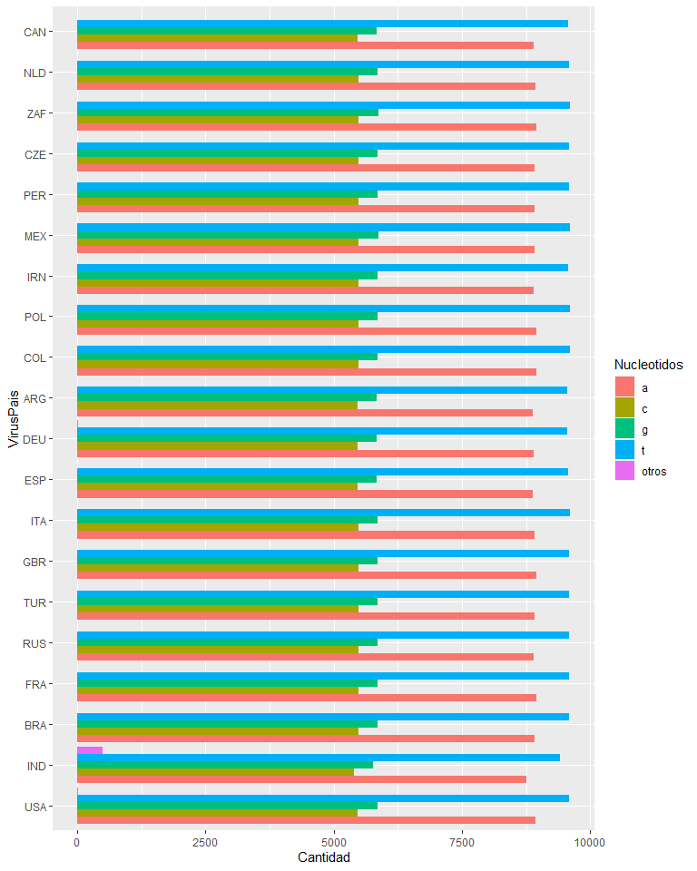

```r
nucsNames <- c("a","c","g","t","otros")
VirusPais <- rep(virusCountries, each=length(nucsNames))
Nucleotidos<-rep(nucsNames,length(virus))
Cantidad <- c()
for(i in 1:length(virus)){
  for(j in 1:4){
    Cantidad<-append(Cantidad,alphabetFrequency(virus)[i,j])
  }
  others <-c(sum(alphabetFrequency(virus)[i,5:18]))
  names(others)<-c("others")
  Cantidad<-append(Cantidad,others)
}

data <- data.frame(VirusPais, Nucleotidos, Cantidad);

#Set as vectores for non alphabetical order
data$VirusPais<-factor(data$VirusPais,levels = unique(data$VirusPais))
data$Nucleotidos<-factor(data$Nucleotidos,levels = unique(data$Nucleotidos))

# Grouped
ggplot(data, aes(fill=Nucleotidos, y=Cantidad, x=VirusPais))+geom_bar(position="dodge", stat="identity")+coord_flip()
```

(Alineación de secuencias múltiples empleando algoritmo de Cluster)

```r
invisible(capture.output(aligned<-AlignSeqs(virus)))
```

### Matriz de distancia

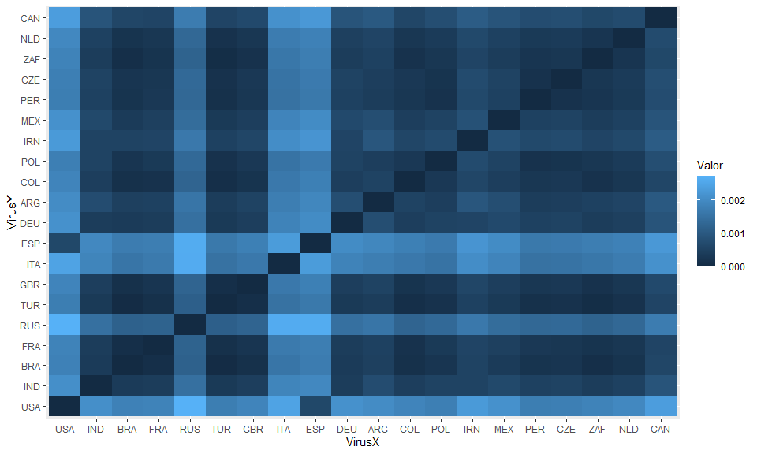

```r
invisible(capture.output(dist<- DistanceMatrix(aligned)));
colnames(dist)<-rownames(dist)<-virusCountries

melted<-melt(dist, value.name=c("Valor"), varnames = c("VirusX","VirusY"));   #reshape2. (melt: from dist matrix to dataframe)
ggplot(data = melted, aes(x=VirusX, y=VirusY, fill=Valor)) + geom_tile();
```

(Construcción de árbol filogenético)

```r
tree <- nj(dist); #ape
dataMSA = tidy_msa(aligned,3500,3550)
dataMSA$name=virusCountries
```

### Análisis jerárquico global de las secuencias

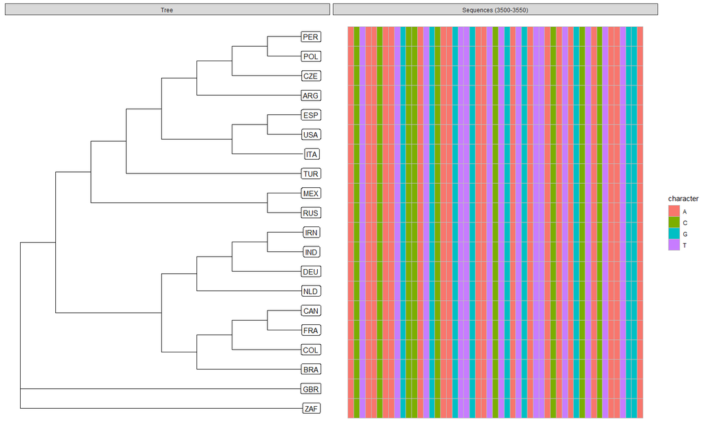

```r
ggtree(tree, branch.length = "none") +
  geom_tiplab(geom = "label", offset =.3, hjust=.7) +
  geom_facet(geom=geom_msa,data=dataMSA,panel='Sequences (3500-3550)',font=NULL,color="Chemistry_NT",mapping = aes(x = position, y = ~name, fill = character)) +
  xlim_tree(1)
```